# Association Rules - Movies

Roberto Baca

08/08/2025

# Association Rules: Movie Recommendation Model (Netflix)

The objective of this project is to apply association rules using R to build a movie recommendation model based on user behavior.

The MovieLens (ml-latest-small) dataset, sourced from a movie recommendation service, will be used. This dataset contains 100,836 ratings for 9,742 movies.

The data was generated by 609 users between March 1996 and September 2018. All selected users rated at least 20 movies. No demographic information is included; each user is identified solely by an ID.

This approach allows for the generation of personalized recommendations without the need for demographic data, relying exclusively on behavioral patterns observed in the ratings.

## ETL: Extract, Transform and Load

```r
# load the dataset
ratings <- read.csv("https://raw.githubusercontent.com/roberbaca/association-rules-movies/refs/heads/main/data/ratings.csv")
movies <- read.csv("https://raw.githubusercontent.com/roberbaca/association-rules-movies/refs/heads/main/data/movies.csv")
```

```r
library(tidyverse)
library(knitr)

#merge the tables
movie_df <- merge(ratings, movies, by="movieId")

# filter the movies rated with 4 or more stars
movie_df_filtered <- subset(movie_df, rating >= 4)

# drop timestamp column
movie_df_filtered <- select(movie_df_filtered, -timestamp)

kable(head(movie_df_filtered))
```

|  | movieId | userId | rating | title | genres |
| --- | --- | --- | --- | --- | --- |
| 1 | 1 | 1 | 4 | Toy Story (1995) | Adventure\|Animation\|Children\|Comedy\|Fantasy |
| 2 | 1 | 555 | 4 | Toy Story (1995) | Adventure\|Animation\|Children\|Comedy\|Fantasy |
| 4 | 1 | 590 | 4 | Toy Story (1995) | Adventure\|Animation\|Children\|Comedy\|Fantasy |
| 5 | 1 | 601 | 4 | Toy Story (1995) | Adventure\|Animation\|Children\|Comedy\|Fantasy |
| 6 | 1 | 179 | 4 | Toy Story (1995) | Adventure\|Animation\|Children\|Comedy\|Fantasy |
| 8 | 1 | 328 | 5 | Toy Story (1995) | Adventure\|Animation\|Children\|Comedy\|Fantasy |

```r
str(movie_df_filtered)
```

```
## 'data.frame':    48580 obs. of  5 variables:
##  $ movieId: int  1 1 1 1 1 1 1 1 1 1 ...
##  $ userId : int  1 555 590 601 179 328 206 468 448 453 ...
##  $ rating : num  4 4 4 4 4 5 5 4 5 5 ...
##  $ title  : chr  "Toy Story (1995)" "Toy Story (1995)" "Toy Story (1995)" "Toy Story (1995)" ...
##  $ genres : chr  "Adventure|Animation|Children|Comedy|Fantasy" "Adventure|Animation|Children|Comedy|Fantasy" "Adventure|Animation|Children|Comedy|Fantasy" "Adventure|Animation|Children|Comedy|Fantasy" ...
```

```r
# unique users
length(unique(movie_df_filtered$userId))
```

```
## [1] 609
```

```r
# movies with rating ≥ 4 stars
length(unique(movie_df_filtered$title))
```

```
## [1] 6297
```

## Conversion to transactions

```r
library(arules)

# create a list of movies per user
user_lists <- split(movie_df_filtered$title, movie_df_filtered$userId)

# convert to transactions
movie_transactions <- as(user_lists, "transactions")

# inspect the second transaction for verification
inspect(movie_transactions[2])
```

```
##     items                                                   transactionID
## [1] {Dark Knight, The (2008),
##      Departed, The (2006),
##      Gladiator (2000),
##      Good Will Hunting (1997),
##      Inception (2010),
##      Inglourious Basterds (2009),
##      Inside Job (2010),
##      Kill Bill: Vol. 1 (2003),
##      Louis C.K.: Hilarious (2010),
##      Mad Max: Fury Road (2015),
##      Shutter Island (2010),
##      Step Brothers (2008),
##      Talladega Nights: The Ballad of Ricky Bobby (2006),
##      The Jinx: The Life and Deaths of Robert Durst (2015),
##      Tommy Boy (1995),
##      Town, The (2010),
##      Warrior (2011),
##      Whiplash (2014),
##      Wolf of Wall Street, The (2013)}                                   2
```

## Frequencies

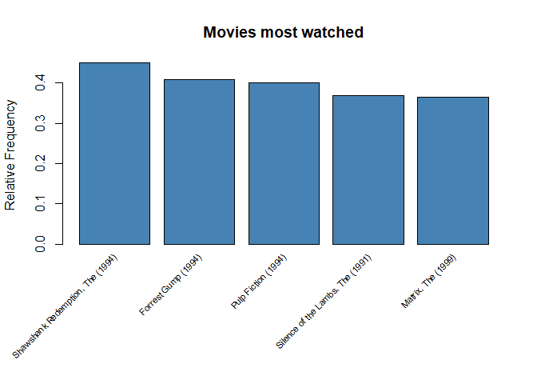

```r
# Top 5 most-watched movies
itemFrequencyPlot(movie_transactions, topN = 5, type = "relative", col = "steelblue", cex.names = 0.7, ylab = "Relative Frequency", main = "Movies most watched")
```

```r
Frequencies <- (head(sort(itemFrequency(movie_transactions), decreasing = TRUE),5))
Frequencies <- round(Frequencies, 2)
tabla <- as.data.frame(Frequencies)
kable(tabla)
```

|  | Frequencies |
| --- | --- |
| Shawshank Redemption, The (1994) | 0.45 |
| Forrest Gump (1994) | 0.41 |
| Pulp Fiction (1994) | 0.40 |
| Silence of the Lambs, The (1991) | 0.37 |
| Matrix, The (1999) | 0.36 |

## Rule generation with Apriori

- Support: How frequently an itemset appears in all transactions (how many times the entire rule appears).
- Confidence: The probability that the item(s) on the right-hand side (consequent) occur given that the left-hand side (antecedent) has occurred.
- Lift: Measures how much more likely the consequent is to occur together with the antecedent compared to occurring separately (by chance).
- Coverage: How many times the antecedent (LHS) appears in the data.

We applied the following parameters:

- At least 3% of users must have rated a given movie combination for it to be considered.
- The probability that a user who watches the left-hand side of the rule also watches the right-hand side must be 60%.
- The maximum length of a rule is 4 items.

```r
rules <- apriori(movie_transactions, parameter = list(supp = 0.03, conf = 0.6, minlen = 2, maxlen = 4))
```

```
## Apriori
##
## Parameter specification:
##  confidence minval smax arem  aval originalSupport maxtime support minlen
##         0.6    0.1    1 none FALSE            TRUE       5    0.03      2
##  maxlen target  ext
##       4  rules TRUE
##
## Algorithmic control:
##  filter tree heap memopt load sort verbose
##     0.1 TRUE TRUE  FALSE TRUE    2    TRUE
##
## Absolute minimum support count: 18
##
## set item appearances ...[0 item(s)] done [0.00s].
## set transactions ...[6297 item(s), 609 transaction(s)] done [0.02s].
## sorting and recoding items ... [641 item(s)] done [0.00s].
## creating transaction tree ... done [0.00s].
## checking subsets of size 1 2 3 4
```

```
##  done [0.10s].
## writing ... [677854 rule(s)] done [0.31s].
## creating S4 object  ... done [0.29s].
```

```r
summary(rules)
```

```
## set of 677854 rules
##
## rule length distribution (lhs + rhs):sizes
##      2      3      4
##   2741 101186 573927
##
##    Min. 1st Qu.  Median    Mean 3rd Qu.    Max.
##   2.000   4.000   4.000   3.843   4.000   4.000
##
## summary of quality measures:
##     support          confidence        coverage            lift
##  Min.   :0.03120   Min.   :0.6000   Min.   :0.03120   Min.   : 1.334
##  1st Qu.:0.03284   1st Qu.:0.6786   1st Qu.:0.04105   1st Qu.: 2.396
##  Median :0.03448   Median :0.7586   Median :0.04762   Median : 2.963
##  Mean   :0.03804   Mean   :0.7673   Mean   :0.05050   Mean   : 3.163
##  3rd Qu.:0.04105   3rd Qu.:0.8462   3rd Qu.:0.05583   3rd Qu.: 3.707
##  Max.   :0.27586   Max.   :1.0000   Max.   :0.44992   Max.   :17.376
##      count
##  Min.   : 19.00
##  1st Qu.: 20.00
##  Median : 21.00
##  Mean   : 23.16
##  3rd Qu.: 25.00
##  Max.   :168.00
##
## mining info:
##                data ntransactions support confidence
##  movie_transactions           609    0.03        0.6
##                                                                                                   call
##  apriori(data = movie_transactions, parameter = list(supp = 0.03, conf = 0.6, minlen = 2, maxlen = 4))
```

```r
# filter the best rules
top_rules <- head(sort(rules, by = "lift"), 5)
inspect(top_rules)
```

```
##     lhs                                                       rhs                                                      support confidence   coverage     lift count
## [1] {Harry Potter and the Half-Blood Prince (2009),
##      Harry Potter and the Order of the Phoenix (2007)}     => {Harry Potter and the Deathly Hallows: Part 1 (2010)} 0.03448276  0.9130435 0.03776683 17.37636    21
## [2] {Harry Potter and the Deathly Hallows: Part 2 (2011),
##      Harry Potter and the Half-Blood Prince (2009)}        => {Harry Potter and the Deathly Hallows: Part 1 (2010)} 0.03612479  0.8800000 0.04105090 16.74750    22
## [3] {Harry Potter and the Deathly Hallows: Part 1 (2010),
##      Harry Potter and the Deathly Hallows: Part 2 (2011)}  => {Harry Potter and the Half-Blood Prince (2009)}       0.03612479  0.9565217 0.03776683 15.74383    22
## [4] {Harry Potter and the Deathly Hallows: Part 1 (2010),
##      Harry Potter and the Order of the Phoenix (2007)}     => {Harry Potter and the Half-Blood Prince (2009)}       0.03448276  0.9545455 0.03612479 15.71130    21
## [5] {Harry Potter and the Deathly Hallows: Part 1 (2010),
##      Harry Potter and the Prisoner of Azkaban (2004)}      => {Harry Potter and the Half-Blood Prince (2009)}       0.03284072  0.9523810 0.03448276 15.67568    20
```

## Visualization of association rules

The relationships can be displayed graphically using a network-type (graph) visualization of the association rules.

```r
library(arulesViz)

plot(top_rules, method = "graph", engine = "htmlwidget")
```

[interactive chart not shown]

A Support vs. Confidence scatter plot visualization can also be used.

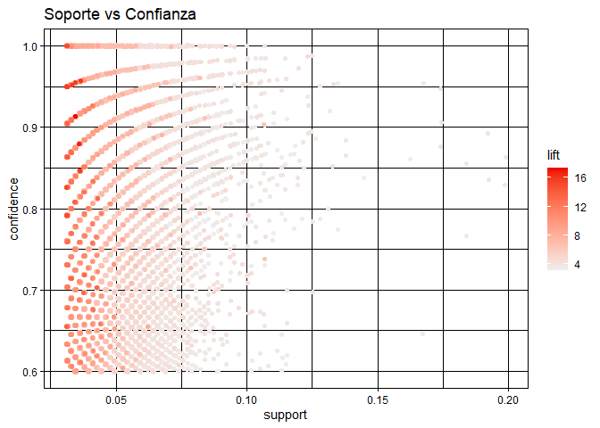

```r
# Scatter plot of rules (Support vs. Confidence, shaded by Lift)

# Retain the rules with the highest lift
rules_subset <- head(sort(rules, by = "lift"), 300000)

# Plot the results
plot(rules_subset, measure=c("support", "confidence"), shading="lift", jitter = 0.1, main="Soporte vs Confianza")
```

## Movie recommendation model

```r
library(arules)

# Function to recommend movies

recomendar_peliculas <- function(rules, user_movies, n = 10) {
  # Filter the rules where all items on the left-hand side are in user_movies
  reglas_usuario <- subset(rules, lhs %ain% user_movies)

  # If no applicable rules are found, return a message
  if (length(reglas_usuario) == 0) {
    cat("No se encontraron reglas aplicables para este usuario.\n")
    return(character(0))
  }

  # Sort the rules by lift in descending order (strongest first)
  reglas_ordenadas <- sort(reglas_usuario, by = "lift", decreasing = TRUE)

  # Extract the recommended movies (right-hand side) from the rules sorted by lift
  recomendadas_ordenadas <- unique(unlist(LIST(rhs(reglas_ordenadas), decode = TRUE)))

  # Remove movies already watched by the user
  recomendadas_ordenadas <- setdiff(recomendadas_ordenadas, user_movies)

  # Return only the first n recommendations
  head(recomendadas_ordenadas, n)

}
```

The script below simulates a new user (not present in the original dataset) who indicates that they liked certain movies, and the system searches for rules where the left-hand side (LHS) matches those movies.

Then, it returns movies on the right-hand side (RHS) as recommendations, ordered according to lift (which measures the strength of the association).

```r
# List of movies watched by the user
user_movies <- c("Avengers, The (2012)")

# Obtain recommendations
recomendaciones <- recomendar_peliculas(rules, user_movies, n = 3)

# Print them numbered
cat("Movies watched by the user:", user_movies, "\n")
```

```
## Movies watched by the user: Avengers, The (2012)
```

```r
cat("Recommended movies:", "\n")
```

```
## Recommended movies:
```

```r
for (i in 1:length(recomendaciones)) {
    cat("[",i,"]", recomendaciones[i], "\n")
}
```

```
## [ 1 ] Guardians of the Galaxy (2014)
## [ 2 ] Iron Man (2008)
## [ 3 ] Dark Knight Rises, The (2012)
```

```r
user_movies <- c("Lion King, The (1994)", "Toy Story (1995)")

recomendaciones <- recomendar_peliculas(rules, user_movies, n = 3)

cat("Movies watched by the user:", user_movies, "\n")
```

```
## Movies watched by the user: Lion King, The (1994) Toy Story (1995)
```

```r
cat("Recommended movies:", "\n")
```

```
## Recommended movies:
```

```r
for (i in 1:length(recomendaciones)) {
    cat("[",i,"]", recomendaciones[i], "\n")
}
```

```
## [ 1 ] Indiana Jones and the Last Crusade (1989)
## [ 2 ] Aladdin (1992)
## [ 3 ] Finding Nemo (2003)
```

```r
user_movies <- c("Alien (1979)", "Predator (1987)", "Terminator, The (1984)")

recomendaciones <- recomendar_peliculas(rules, user_movies, n = 3)

cat("Movies watched by the user:", user_movies, "\n")
```

```
## Movies watched by the user: Alien (1979) Predator (1987) Terminator, The (1984)
```

```r
cat("Recommended movies:", "\n")
```

```
## Recommended movies:
```

```r
for (i in 1:length(recomendaciones)) {
    cat("[",i,"]", recomendaciones[i], "\n")
}
```

```
## [ 1 ] Terminator 2: Judgment Day (1991)
## [ 2 ] Star Wars: Episode V - The Empire Strikes Back (1980)
## [ 3 ] Star Wars: Episode VI - Return of the Jedi (1983)
```